# Data Analysis on financial/health-related effect of Storms in US

Andrew Crena

2023-03-21

# Reproducible Research Assignment 2

## In this assignment, we will be analyzing data from the U.S. National Oceanic and Atmospheric Administration’s (NOAA) storm database.More specifically, we want to further understand the econonmic and health-related ramifications of various types of natural disaster events. By identifying certain types of storms and the various degrees of damge they cause, we can better prepare for the future.

## Data Processing

### First, we will load in the data, and get a better understanding of what we are looking at.

```r
setwd("~/R_Programming/DATASETS")
noaaDF <- read.csv(bzfile('repdata_data_StormData.csv.bz2'),header=TRUE, stringsAsFactors = FALSE)
str(noaaDF)
```

```
## 'data.frame':    902297 obs. of  37 variables:
##  $ STATE__   : num  1 1 1 1 1 1 1 1 1 1 ...
##  $ BGN_DATE  : chr  "4/18/1950 0:00:00" "4/18/1950 0:00:00" "2/20/1951 0:00:00" "6/8/1951 0:00:00" ...
##  $ BGN_TIME  : chr  "0130" "0145" "1600" "0900" ...
##  $ TIME_ZONE : chr  "CST" "CST" "CST" "CST" ...
##  $ COUNTY    : num  97 3 57 89 43 77 9 123 125 57 ...
##  $ COUNTYNAME: chr  "MOBILE" "BALDWIN" "FAYETTE" "MADISON" ...
##  $ STATE     : chr  "AL" "AL" "AL" "AL" ...
##  $ EVTYPE    : chr  "TORNADO" "TORNADO" "TORNADO" "TORNADO" ...
##  $ BGN_RANGE : num  0 0 0 0 0 0 0 0 0 0 ...
##  $ BGN_AZI   : chr  "" "" "" "" ...
##  $ BGN_LOCATI: chr  "" "" "" "" ...
##  $ END_DATE  : chr  "" "" "" "" ...
##  $ END_TIME  : chr  "" "" "" "" ...
##  $ COUNTY_END: num  0 0 0 0 0 0 0 0 0 0 ...
```

[output cut: 23 more lines]

### Next, we will load the packages necessary.

```r
library(ggplot2)
library(dplyr)
library(lubridate)
library(tidyr)
```

## Question 1

### After reading the structure of the data, we will now address the first question of the health-related effects, focusing on fatality and injury data.

```r
totalfat <- aggregate(noaaDF$FATALITIES, by = list(noaaDF$EVTYPE), "sum")
names(totalfat) <- c("Event", "Fatalities")
totalfatsorted <- totalfat[order(-totalfat$Fatalities), ][1:20, ]
totalfatsorted
```

```
##                       Event Fatalities
## 834                 TORNADO       5633
## 130          EXCESSIVE HEAT       1903
## 153             FLASH FLOOD        978
## 275                    HEAT        937
## 464               LIGHTNING        816
## 856               TSTM WIND        504
## 170                   FLOOD        470
## 585             RIP CURRENT        368
## 359               HIGH WIND        248
## 19                AVALANCHE        224
## 972            WINTER STORM        206
## 586            RIP CURRENTS        204
## 278               HEAT WAVE        172
## 140            EXTREME COLD        160
## 760       THUNDERSTORM WIND        133
## 310              HEAVY SNOW        127
## 141 EXTREME COLD/WIND CHILL        125
## 676             STRONG WIND        103
## 30                 BLIZZARD        101
## 350               HIGH SURF        101
```

#### now, for injuries

```r
totalinj <- aggregate(noaaDF$INJURIES, by = list(noaaDF$EVTYPE), "sum")
names(totalinj) <- c("Event", "Injuries")
totalinjsorted <- totalinj[order(-totalinj$Injuries), ][1:20, ]
totalinjsorted
```

```
##                  Event Injuries
## 834            TORNADO    91346
## 856          TSTM WIND     6957
## 170              FLOOD     6789
## 130     EXCESSIVE HEAT     6525
## 464          LIGHTNING     5230
## 275               HEAT     2100
## 427          ICE STORM     1975
## 153        FLASH FLOOD     1777
## 760  THUNDERSTORM WIND     1488
## 244               HAIL     1361
## 972       WINTER STORM     1321
## 411  HURRICANE/TYPHOON     1275
## 359          HIGH WIND     1137
## 310         HEAVY SNOW     1021
## 957           WILDFIRE      911
## 786 THUNDERSTORM WINDS      908
## 30            BLIZZARD      805
## 188                FOG      734
## 955   WILD/FOREST FIRE      545
## 117         DUST STORM      440
```

### I am going to use bar plots to observe what events are considered the biggest threat to population health via Injuries and Fatalities

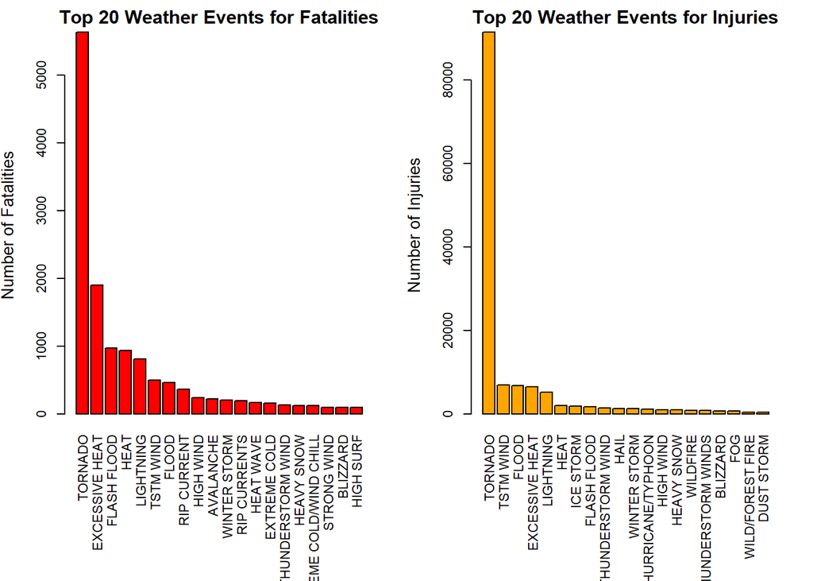

```r
par(mfrow = c(1, 2), mar = c(10, 4, 2, 2), las = 3, cex = 0.7,
    cex.main = 1.4, cex.lab = 1.2)
barplot(totalfatsorted$Fatalities, names.arg = totalfatsorted$Event,
        col = 'red', main = 'Top 20 Weather Events for Fatalities',
        ylab = 'Number of Fatalities')
barplot(totalinjsorted$Injuries, names.arg = totalinjsorted$Event,
        col = 'orange', main = 'Top 20 Weather Events for Injuries',
        ylab = 'Number of Injuries')
```

### The graphs show that tornadoes are the most harmful events in terms of fatalities and injuries accrued from the event. While tornadoes top this list, it is worth noting that events related to flooding (flash floods, floods) and heat(excessive heat, heat) appear to be the next most harmful tpes of events.

## Question 2

## We now want to observe the economic factor to our assignment. For this analysis, I will measure the ramifications based off of damage to property and crops. We will use a similar strategy as the first question when working with the data.

### First, we will calculate property damage

```r
totalpropdam <- aggregate(noaaDF$PROPDMG, by = list(noaaDF$EVTYPE), "sum")
names(totalpropdam) <- c("Event", "Property")
totalpropsorted <- totalpropdam[order(-totalpropdam$Property), ][1:20, ]
totalpropsorted
```

```
##                    Event   Property
## 834              TORNADO 3212258.16
## 153          FLASH FLOOD 1420124.59
## 856            TSTM WIND 1335965.61
## 170                FLOOD  899938.48
## 760    THUNDERSTORM WIND  876844.17
## 244                 HAIL  688693.38
## 464            LIGHTNING  603351.78
## 786   THUNDERSTORM WINDS  446293.18
## 359            HIGH WIND  324731.56
## 972         WINTER STORM  132720.59
## 310           HEAVY SNOW  122251.99
## 957             WILDFIRE   84459.34
## 427            ICE STORM   66000.67
## 676          STRONG WIND   62993.81
## 376           HIGH WINDS   55625.00
## 290           HEAVY RAIN   50842.14
## 848       TROPICAL STORM   48423.68
## 955     WILD/FOREST FIRE   39344.95
## 164       FLASH FLOODING   28497.15
## 919 URBAN/SML STREAM FLD   26051.94
```

#### next, for damage to crops!

```r
totalcropdam <- aggregate(noaaDF$CROPDMG, by = list(noaaDF$EVTYPE), "sum")
names(totalcropdam) <- c("Event", "Crop")
totalcropsorted <- totalcropdam[order(-totalcropdam$Crop), ][1:20, ]
totalcropsorted
```

```
##                  Event      Crop
## 244               HAIL 579596.28
## 153        FLASH FLOOD 179200.46
## 170              FLOOD 168037.88
## 856          TSTM WIND 109202.60
## 834            TORNADO 100018.52
## 760  THUNDERSTORM WIND  66791.45
## 95             DROUGHT  33898.62
## 786 THUNDERSTORM WINDS  18684.93
## 359          HIGH WIND  17283.21
## 290         HEAVY RAIN  11122.80
## 212       FROST/FREEZE   7034.14
## 140       EXTREME COLD   6121.14
## 848     TROPICAL STORM   5899.12
## 402          HURRICANE   5339.31
## 164     FLASH FLOODING   5126.05
## 411  HURRICANE/TYPHOON   4798.48
## 957           WILDFIRE   4364.20
## 873     TSTM WIND/HAIL   4356.65
## 955   WILD/FOREST FIRE   4189.54
## 464          LIGHTNING   3580.61
```

### Just as I did for question 1, we will put two bar plots on the same plot in order to visualize our data in relation to property and crop damage.

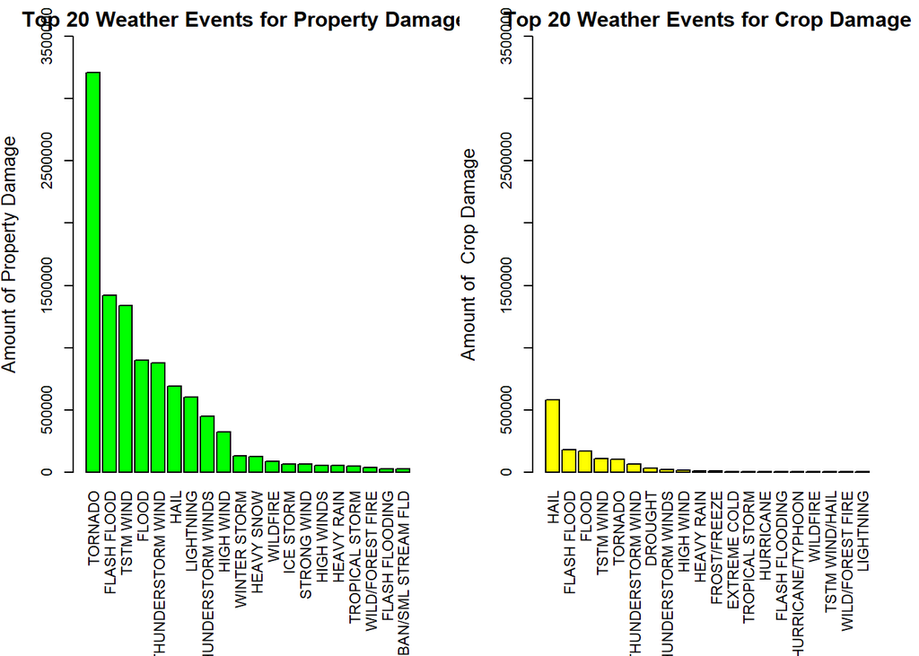

```r
par(mfrow = c(1, 2), mar = c(10, 4, 2, 2), las = 3, cex = 0.7,
    cex.main = 1.4, cex.lab = 1.2)
barplot(totalpropsorted$Property, names.arg = totalpropsorted$Event,
        col = 'Green', main = 'Top 20 Weather Events for Property Damage ',
        ylab = 'Amount of Property Damage', ylim = c(0, 3500000))
barplot(totalcropsorted$Crop, names.arg = totalcropsorted$Event,
        col = 'Yellow',main = 'Top 20 Weather Events for Crop Damage',
        ylab = 'Amount of  Crop Damage', ylim = c(0, 3500000))
```

### Now, let’s combine crop and property damage, in order to further understand the difference in total damage accrued by each.

```r
totalevcost <- aggregate(noaaDF$CROPDMG+noaaDF$PROPDMG,
                         by = list(noaaDF$EVTYPE), "sum")
names(totalevcost) <- c("Event", "TotalCost")
totalcostsorted <- totalevcost[order(-totalevcost$TotalCost), ][1:20, ]
totalcostsorted
```

```
##                  Event  TotalCost
## 834            TORNADO 3312276.68
## 153        FLASH FLOOD 1599325.05
## 856          TSTM WIND 1445168.21
## 244               HAIL 1268289.66
## 170              FLOOD 1067976.36
## 760  THUNDERSTORM WIND  943635.62
## 464          LIGHTNING  606932.39
## 786 THUNDERSTORM WINDS  464978.11
## 359          HIGH WIND  342014.77
## 972       WINTER STORM  134699.58
## 310         HEAVY SNOW  124417.71
## 957           WILDFIRE   88823.54
## 427          ICE STORM   67689.62
## 676        STRONG WIND   64610.71
## 290         HEAVY RAIN   61964.94
## 376         HIGH WINDS   57384.60
## 848     TROPICAL STORM   54322.80
## 955   WILD/FOREST FIRE   43534.49
## 95             DROUGHT   37997.67
## 164     FLASH FLOODING   33623.20
```

### This will allow us to make our final plot, showing total damage from crops and properties combined.

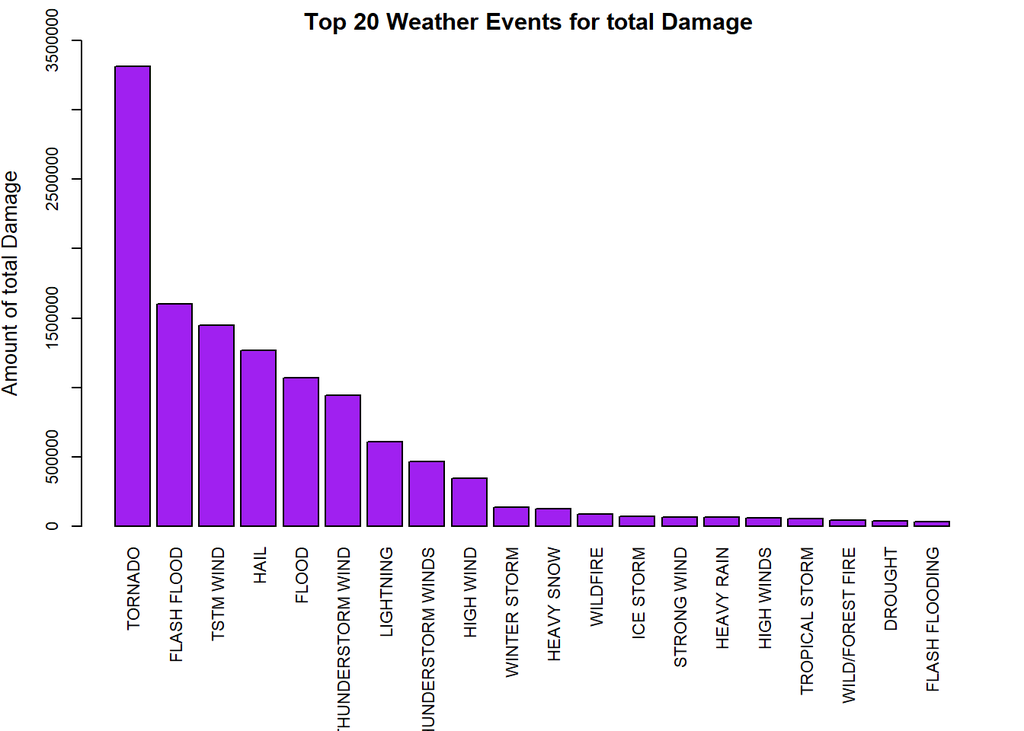

```r
par(mfrow = c(1,1), mar = c(10, 4, 2, 2), las = 3, cex = 0.7,
    cex.main = 1.4, cex.lab = 1.2)
barplot(totalcostsorted$TotalCost, names.arg = totalcostsorted$Event,
        col = 'Purple',main = 'Top 20 Weather Events for total Damage ',
        ylab = 'Amount of total Damage', ylim = c(0, 3500000))
```

### The bar plot shows that tornadoes, similar to health-related damage, are the most harmful in terms of economic effect. It is important to remember that the complexities of the financial damage that comes after these events is difficult to fully understand, but this gives us a good idea of the ramifications.

## Results

### After analyzing the damage of certain natural disasters, tornadoes appear to be the most harmful not only in terms of health (fatalities/injuries), but in terms of economic damage as well (damage to property and crops)